[figure not shown]

# Tori (Trend- & oversell-based rebalancing instructions) in SunLife Rainbow MPF Scheme

# 永明彩虹強積金應用TORI進行資產調配

## Earliest data available from 2001/09/17

## 數據由2001/09/17開始

Reminder: Sun Life Rainbow MPF Scheme is a biased scheme with a single outperforming fund, SREPHKZ.  
Risk-tolerating investor might consider a SAA portfolio using SREPHKZ for better return.  
備註：永明彩虹強積金為一高度側重香港股票基金(SREPHKZ)的強積金計劃。  
有能力承擔更高風險的投資者可考慮以固定比率方式加入SREPHKZ以爭取最大回報。

## Disclaimer

1. The author (jchan-gi) expressly stated that nothing my repositories and webpages constitutes any advices or recommendation on investing or allocating assets on any stock or financial products.
2. No content in my study have been prepared with respect to specific personal need and investment objects of individuals. All materials reveal to the public are applicable to the author (jchan-gi) only.
3. All results from this repository are simulated from historical data only. It may portray inaccurate information and hence the repository must not applied in production and must used as academic exchange only. The author is not responsible in any loss induced from using this repository.
4. All investors shall obtain kind advices from professional financial consultants before making any decisions. Professional financial consultants should recommend products or decisions that suit your needs and objectives.
5. The author is not licensed nor professional in the field hence this studies are not professional advice and may not be suitable for anyone except myself.
6. You shall not invest on any financial products using the information on this code repository, website or any information made public by jchan-gi alone. You agree you have fully understand and willing to undertake the risks of this script in any circumstances involves in using this script.
7. English version shall be used if any discrepencies exists between English and Chinese version.

## 免責聲明

1. 本文作者現此聲明，本人的程式及網頁並非對閤下提供或作出對任何金融產品的投資或資產調配的建議。
2. 本文內容沒有針對閣下或其他人的實際個人需要而編撰。所有公開的內容只適用於本文作者。
3. 本文內容根據歷史數據模擬回報率等一切資訊。該等資訊可能非常不準確，本文及程式庫任何內容不應於實際環境使用，及只供學術討論。如因使用本程式庫任何內容而招致損失，作者一概不會負責。
4. 所有投資者應在作出任何決定前，先向專業理財顧問查詢及要求提供意見。只有理財顧問的意見才能符合閣下的實際理財需要及風險胃納。
5. 本文作者非專業人士或持牌從業者，因此，本文內容並非專業意見。而且，本文內容極有可能並不合適於除作者以外的任何人。
6. 在作出任何投資決定前，你不應單靠此程序作出決定。當你作出任何與本程序算法有關的投資決定時，你已完全知悉並願意接受本程序或算法所帶來的風險。
7. 本聲明如有歧義，將以英文版本作準。

## 最後更新日期 Last update: 2020/08/13.

### 更新記錄

2020-08-13 v3.0.2bII  
Update parameters of Sun Life Rainbow scheme.  
修改永明彩虹強積金計畫的參數。

2020-08-13 v3.0.2b  
Repair calcuation method of IRR.  
修正內部回報率IRR的計算方式。

2020-08-11 v3.0.1bII  
Update project dependencies (Python part).  
更新所需Python程式庫。

2020-08-03 v3.0.1b  
Release results accounted up to 2020/07/30.  
公佈直至2020/07/30的結果。

2020-07-29 v3.0.1a  
NAV storage media are now using SQLite3 database for capability in automated loading.  
改用SQLite3數據庫儲存NAV以加強支援自動載入功能。

2020-07-25 v3.0.0a  
Release results accounted up to 2020/06/30.  
公佈直至2020/06/30的結果。

2020-07-24 v3.0.0rc1  
Converted to Jupyter Notebook + R format for better performance.  
轉換成Jupyter Notebook + R方式計算。

2020-05-03 v2.1.3b  
Release results accounted up to 2020/04/28.  
公佈直至2020/04/28的結果。

2020-04-02 v2.1.3a  
Release results accounted up to 2020/03/31.  
公佈直至2020/03/31的結果。

2020-03-31 v2.1.2 Version synchronize before uploading 2020Q1 results.  
將所有程式版本同步，以準備發佈2020Q1結果。

2020-03-27 v2.1.1a

1. Fix return matrix column misalignment in Tori @ SunLife.
2. Fix faulty code on inconsistent total asset price across time. Description: Subsetting would not work to produce consistent total asset value when the data is splited by train-test partition. This is due to the hedge flag detect the future signal if the subsetting is being applied to the weight but not the return. This is a characteristics of Return.portfolio but not a glitch of the algorithm.
3. 修正回報欄位錯置。
4. 修正於不同時間下出現不一致的總資產。

2020-03-25 v2.1.1

1. Adding Golden Butterfly Portfolio as a benchmark portfolio.
2. 增加Golden Butterfly Portfolio作為基準指標。

2020-03-24 v2.1

1. Further diversify the hedge mode with Sixty-Fifth Plus Fund.
2. Performance indicator calculation on first installment revised extensively, includes:
- Adding SPY (SPDR S&P 500 ETF), QQQ (Invesco QQQ Trust), and HSI (Hang Seng Index) as a benchmark.
- Captial Asset Pricing Model CAPM and Information Ration results are available. (The author disapprove the use of CAPM, the results of CAPM are for reference only)
- Charting with benchmark are accomplished through tidyquant and ggplot now.
1. 使用65歲後基金進一步分散避險狀態下的風險。
2. 計算第一期投資的回報已作出重大修改，包括：  
   加入SPY,QQQ及恒生指數作基準  
   以三項基準計算資本資產定價模型CAPM及資訊比率Information Ratio的比較。（作者不認同CAPM是有效的評估方法。數值僅供參考。）  
   圖表改以tidyquant + ggplot展示，並加入與基準的比較。

2020-03-18 v2

1. Separate the return used in calculating AKANE, TORI (log) and return (simple).
2. 修正計算回報時使用的方式

2020-01-17 v1.1

1. Minor enhancement on background information.
2. 更改背景資料

2020-01-13 v1

1. TORI is officially published and backtested with SunLife Rainbow MPF
2. 正式推出以永明彩虹強積金作回測的TORI介紹

## WARNING: Please understand nature of Tori in this section before reading further:

This script relies on BIAS indicator and RSI indicator for investment rebalancing.  
Please understand BIAS indicator and RSI indicator before reading further.  
The script perform walk-forward validation only.  
A model will be created for exactly next re-balance only based on most updated data for that moment.  
There is no other validation or assessment on the data.  
Please be reminded that backtesting and/or walk-forward validation is no way to be accurate in predicting future performance.  
Using this script may exposed to various risk, including but not limited to overfitting, market, timing, etc.

## 警告：在應用Tori之前，請先於此節了解TORI的特性

Tori根據乖離值及相對強弱指數作投資組合再配置。  
閱讀下文前，請先了解乖離值及相對強弱指數。  
此模式只使用了前移式回測(walk-forward validation)。  
每次資產調配都會基於擁有當時而言的最新資料。  
然而，請切記過往表現不代表將來表現。  
使用此代碼將會受到包括但不限於以下的風險所影響：過擬合風險、市場風險、時差風險等。

## Background Introduction

Mandatory Provident Fund (MPF) is one of the legal pensions in Hongkong.  
All Employers and some employees are required to pay at least 5% of monthly salary to MPF services provider.  
MPF providers are required to provide approved funds for employees to invest, while the team could earn management fees.

However, the average annualized return of MPF is 3.1% only in from 2000-2016 (Mandatory Provident Fund Schemes Authority, 2016).  
Most Hongkong employees feels they are forced to give their salary to MPF fund manager.  
Indeed, the reasons of low return may due to inactive management by employees.  
In this example, we will explore n-m MA BIAS to rise the annualized return in Tori.

## 背景簡介

在香港，強積性公積金(強積金, Mandatory Provident Fund, MPF)是其中一種法定退休金。  
僱主及部份僱員須扣除5%薪金供強積金營運商。  
強積金營運商將每月收取管理費，並提供認可基金供僱員作投資儲蓄。  
但是，強積金的平均回報僅3.1%，因而被批評回報有三份之一被基金經理蠶食。  
誠言，每位僱員如以主動方式管理強積金，有助提升回報而減少收費的影響。  
這文記錄了作者以時差平均線乖離率(n-m MA BIAS)提升強積金回報的探索(即Tori)。

## Tori used NMMA BIAS & Relative Strength Index (RSI)

The author used n-m MA BIAS indicator (NMMA BIAS) to extract trend and RSI for overbuy/oversell status in Tori.  
This script combine two indicators and consider recent stock returns for the three outcome:

1. Tactical Asset Allocation (TAA) using Tori
2. Strategic Asset Allocation (SAA) using Tori and designated funds
3. Hedging mode (cash mode)

作者嘗試以時差平均線乖離率(n-m MA BIAS, NMMA BIAS)及相對強弱指數(RSI)分配投資物。  
時差平均線乖離率的預測考慮了投資物的趨勢(Trend)。 相對強弱指數則考慮投資物的超買超賣狀態。  
本程序結合兩項指標後，再考慮考慮最近三至六個月回報後，程式將自動決定以TORI佈置戰術性資產部署(tactical asset allocation, TAA) 、或是以TORI結果配合債券及現金的策略性資產部署(Strategic asset allocation)、或進入避險模式。

### When to manage my portfolio using Tori?

The author collect historical pricing in the last day of every month to calculate NMMA BIAS and RSI in Tori.  
The same day would be the day of successful rebalance.  
In this example, MPF would have T+2 time delay for obtaining historical price, hence it is expected to have timing risks in Tori in MPF.

### 何時使用Tori管理及調配投資組合?

作者以每月最後一日取得投資物的歷史價格計算每月回報、NMMA BIAS及相對強弱指數。  
然後於同日重新配置投資物。  
在本示例中，強積金大部分均有T+2的時延，因此實際操作將有時延誤差。

### Tori in action: Walk-forwark validation results

### Tori 前移式回測結果

Bottom of page 本頁底部

```python
# Import section

# Internal packages
import decimal
import math
import datetime
import os

# Computation packages
import numpy as np
import numpy_financial as npf
import pandas as pd
from pyarrow import feather as f
import sqlite3 as sql3


from statsmodels.distributions.empirical_distribution import ECDF
import talib

# RPy2 packages
import rpy2.robjects as ro
from rpy2.robjects import pandas2ri, numpy2ri
numpy2ri.activate()
pandas2ri.activate()

from rpy2.robjects.packages import importr
from rpy2.robjects.pandas2ri import py2rpy as p2r
from rpy2.robjects.pandas2ri import rpy2py as r2p


# Import R packages
quantmod = importr('quantmod')
ttr = importr('TTR', robject_translations =  {".env": "__env_ttr__"})
xts = importr('xts', robject_translations = {".subset.xts": "_subset_xts2",
                                             "to.period": "to_period2"})
```

```python
# Constant defintion

# Paths
WORKSPACE_DIR = './'
DB_PATH = os.path.join(WORKSPACE_DIR, 'raw_data/mpf_sunlife_rainbow.sqlite')

# trading days
TRADING_DAYS = 21
EVALUATE_TO = '2020/07/30'

# n-m MA BIAS parameters
MA_PERIOD_LONG = 6
MA_PERIOD_SHORT = 2
NM_LAG = 1

# RSI-weighted parameters
RSI_OVERBUY = 0.85
RSI_OVERBUY_VALUE = 0.4
RSI_OVERBUY_FALSE_VALUE = 1.4
RSI_PERIOD = 18

# nmMA calculation parameters
MIN_NMMA = 0.00002
DOWN_N_QUANTILE = 0.35
DOWN_O_QUANTILE = 0.45
EOHEDGE_N_QUANTILE = 0.45
EOHEDGE_O_QUANTILE = 0.35
GREEDY_MARKET_O_QUANTILE = 0.75
GREEDY_MARKET_N_QUANTILE = 0

# Fund Parameters
TOP_FUNDS = 2

EQUITY = [2, 3, 4, 5, 6]
MIXED_ASSET_HIGH = [10, 11]
MIXED_ASSET_LOW = [0, 1]
MONEY_MARKET = [9]
FIXED_INCOME = [7, 8]

HIGH_RISKS = []
HIGH_RISKS.extend(EQUITY)
HIGH_RISKS.extend(MIXED_ASSET_HIGH)
LOWER_RISKS = []
LOWER_RISKS.extend(MIXED_ASSET_LOW)
LOWER_RISKS.extend(FIXED_INCOME)
LOWER_RISKS.extend(MONEY_MARKET)

# Hedge mixing weight
HEDGE_COMPONENTS = [9, 8, 1]
HEDGE_MIX_RETURN = -0.07
HEDGE_FULL_WEIGHT = {HEDGE_COMPONENTS[0]: [100, 50, 30], HEDGE_COMPONENTS[1]: [None, 50, 30], HEDGE_COMPONENTS[2]: [None, None, 40]}
HEDGE_MIX_WEIGHT = {HEDGE_COMPONENTS[0]: [30, 10, 8], HEDGE_COMPONENTS[1]: [None, 20, 10], HEDGE_COMPONENTS[2]: [None, None, 12]}
```

```python
%%capture
# Function declaration
def ecdf(x):
    last_value = x.tail(1)
    temp_ecdf = ECDF(x)
    if temp_ecdf(last_value) >= (RSI_OVERBUY - 1/math.sqrt(x.size)):
        return RSI_OVERBUY_VALUE
    else:
        return RSI_OVERBUY_FALSE_VALUE-math.pow(temp_ecdf(last_value),2)

def check_down(stock_return, i, up, new_quantile=DOWN_N_QUANTILE, old_quantile=DOWN_O_QUANTILE):
    if i > 7 and stock_return.iloc[i] < stock_return.iloc[0:(i+1)].quantile(new_quantile) and \
        stock_return.iloc[i-3] < stock_return.iloc[0:(i+1)].quantile(old_quantile):
        up = False
    return up

def check_end_of_hedge(stock_return, i, up, hedge, new_quantile=EOHEDGE_N_QUANTILE, old_quantile=EOHEDGE_O_QUANTILE):
    if i > 7 and hedge and stock_return.iloc[i] > stock_return.iloc[0:(i+1)].quantile(new_quantile) and \
        stock_return.iloc[i-3] > stock_return.iloc[0:(i+1)].quantile(old_quantile):
        up = True
        hedge = False
    return (up, hedge)
def check_greedy_hedge(stock_return, i, hedge, new_quantile = GREEDY_MARKET_N_QUANTILE, old_quantile=GREEDY_MARKET_O_QUANTILE):
    if i > 7 and stock_return.iloc[i] < new_quantile and \
        stock_return.iloc[i-1] > stock_return.iloc[0:(i+1)].quantile(old_quantile):
        hedge = True
    return hedge


ro.r('''
    r_hedge_down <- function(portf_return, month, draw_down, up, hedge){
        library("PerformanceAnalytics")
        month.date <- as.Date(month, "%Y-%m-%d")
        p.return.xts <- as.xts(portf_return, order.by = month.date)
        is.nan.xts <- function(x) {
            do.call(cbind, lapply(x, is.nan))
        }

        p.return.xts[is.nan(p.return.xts)] <- NA
        mpf.portf.drawdown <- Drawdowns(p.return.xts, geometric=TRUE)
        if (tail(na.omit(mpf.portf.drawdown), 1) < -0.065 && up == FALSE) {
            hedge <- TRUE
        }
        r <- hedge
    }

    r_portf <- function(return, weight, i, month){
        library("PerformanceAnalytics")
        month.date <- as.Date(month, "%Y-%m-%d")

        row <- i+1
        is.nan.xts <- function(x) {
            do.call(cbind, lapply(x, is.nan))
        }

        return.xts <- as.xts(return, order.by = month.date)
        return.xts[is.nan(return.xts)] <- NA
        weight.xts <- as.xts(weight, order.by = month.date)
        weight.xts[is.nan(weight.xts)] <- NA

        if (row == 1) {
            r <- sum(na.fill(return.xts[row,],0) * weight.xts[row,])
        } else {
            r <- Return.portfolio(
                na.fill(return.xts[1:row,], 0),
                weight = weight.xts[1:row,],
                geometric = TRUE,
                rebalance_on = "months"
            )
        }
    }

    r_annual <- function(portf_return, month){
        library("PerformanceAnalytics")
        month.date <- as.Date(month, "%Y-%m-%d")
        portf.rebal.fm <- as.xts(portf_return, order.by = month.date)
        temp <- Return.annualized(portf.rebal.fm, geometric = TRUE)
    }

''')
```

```python
# Read SQLite3 Connection
conn = sql3.connect(DB_PATH)
dcur = conn.cursor()

dcur.execute('SELECT * FROM slrMpfNav')
mpf_sunlife_db = dcur.fetchall()
conn.close()

# Table reshape
mpf_sunlife = pd.DataFrame(mpf_sunlife_db, columns=['id', 'Date', 'Fund', 'Nav']).drop('id', axis=1)
mpf_sunlife = mpf_sunlife.drop('Date', axis=1).set_index(pd.to_datetime(mpf_sunlife['Date'],format="%Y/%m/%d"))
mpf_sunlife = mpf_sunlife.pivot(columns='Fund', values='Nav').reset_index()
mpf_sunlife = mpf_sunlife.drop('Date', axis=1).set_index(pd.to_datetime(mpf_sunlife['Date'],format="%Y/%m/%d"))
mpf_sunlife = mpf_sunlife.truncate(after=pd.to_datetime(EVALUATE_TO, format='%Y/%m/%d'))
daily_str = np.datetime_as_string(mpf_sunlife.index.values, unit='D')
```

```python
sma_long = lambda x: talib.SMA(x, TRADING_DAYS*MA_PERIOD_LONG)
sma_short = lambda x: talib.SMA(x, TRADING_DAYS*MA_PERIOD_SHORT)
rsi = lambda x: talib.RSI(x, TRADING_DAYS*RSI_PERIOD)

mpf_sunlife_sma_l = mpf_sunlife.apply(sma_long)
mpf_sunlife_sma_s = mpf_sunlife.apply(sma_short)
mpf_sunlife_rsi = mpf_sunlife.apply(rsi)
```

```python
log = lambda x: np.log(x) - np.log(x.shift(1))
mpf_sunlife_monthly = mpf_sunlife.groupby(pd.Grouper(freq='BM')).last()
mpf_sunlife_monthly_simple = mpf_sunlife_monthly.pct_change()
mpf_sunlife_monthly_simple.iloc[0,:] = (mpf_sunlife_monthly.iloc[0,:] - mpf_sunlife.iloc[0,:]) / mpf_sunlife.iloc[0,:]

mpf_sunlife_monthly_log = mpf_sunlife_monthly.apply(log)
mpf_sunlife_monthly_log.iloc[0,:] = np.log(mpf_sunlife_monthly.iloc[0,:]) - np.log(mpf_sunlife.iloc[0,:])

monthly_str = np.datetime_as_string(mpf_sunlife_monthly_simple.index.values, unit='D')
```

```python
mpf_sunlife_rsi_monthly = mpf_sunlife_rsi.fillna(0).groupby(pd.Grouper(freq='BM')).mean()
mpf_sunlife_rsi_ecdf = mpf_sunlife_rsi_monthly.copy().fillna(0)
mpf_sunlife_rsi_ecdf = mpf_sunlife_rsi_ecdf.where(mpf_sunlife_rsi_ecdf != np.nan, 0)

mpf_sunlife_rsi_monthly_ecdf = mpf_sunlife_rsi_monthly.expanding(1).apply(lambda x: ecdf(x))
#mpf_sunlife_rsi_monthly_ecdf.MPFC = 1
mpf_sunlife_rsi_monthly_ecdf = mpf_sunlife_rsi_monthly_ecdf.apply(lambda x: x / float(x.sum()), axis=1).pow(0.25)
```

```python
mpf_sunlife_bias_diff = (mpf_sunlife_sma_s - mpf_sunlife_sma_l)/(mpf_sunlife_sma_l)
mpf_sunlife_bias_diff_dt = (mpf_sunlife_bias_diff - mpf_sunlife_bias_diff.shift(TRADING_DAYS*1)).fillna(0).groupby(pd.Grouper(freq='BM')).mean()
mpf_sunlife_bias_diff_dt = mpf_sunlife_bias_diff_dt * mpf_sunlife_rsi_monthly_ecdf
mpf_sunlife_stock_return = mpf_sunlife_monthly_log.iloc[:,HIGH_RISKS].mean(axis=1)

mpf_sunlife_bias_diff_dt.fillna(0)
#mpf_sunlife_bias_diff_dt.iloc[:,] = np.where(mpf_sunlife_bias_diff_dt.iloc[:,] < 0, 0, mpf_sunlife_bias_diff_dt.iloc[:,])
mpf_sunlife_bias_diff_dt.iloc[:,HIGH_RISKS] = np.where(mpf_sunlife_bias_diff_dt.iloc[:,HIGH_RISKS] < 1e-6, 0, mpf_sunlife_bias_diff_dt.iloc[:,HIGH_RISKS])
mpf_sunlife_bias_diff_dt.iloc[:,LOWER_RISKS] = np.where(mpf_sunlife_bias_diff_dt.iloc[:,LOWER_RISKS] < 0, 0, mpf_sunlife_bias_diff_dt.iloc[:,LOWER_RISKS])
mpf_sunlife_bias_diff_dt = mpf_sunlife_bias_diff_dt.mask(mpf_sunlife_bias_diff_dt.rank(axis=1, method="min", ascending=False) > TOP_FUNDS, 0)


num_of_months = mpf_sunlife_bias_diff_dt.shape[0]

mpf_sunlife_bias_p = pd.DataFrame().reindex_like(mpf_sunlife_bias_diff_dt).fillna(0).astype(int)
mpf_portf_weight = pd.DataFrame().reindex_like(mpf_sunlife_monthly_simple).fillna(0).astype(np.float64)
mpf_sunlife_portf_return = np.zeros(num_of_months)

r_portf = ro.globalenv['r_portf']
r_hedge_down = ro.globalenv['r_hedge_down']

up = True
hedge = False

for i in range(num_of_months):
    up = check_down(mpf_sunlife_stock_return, i, up)
    up, hedge = check_end_of_hedge(mpf_sunlife_stock_return, i, up, hedge)
    hedge = check_greedy_hedge(mpf_sunlife_stock_return, i, hedge)

    mpf_sunlife_sum = mpf_sunlife_bias_diff_dt.iloc[i,:].sum()
    #print(mpf_sunlife_sum)
    if i <= 11 or mpf_sunlife_sum == mpf_sunlife_bias_diff_dt.iloc[i,MONEY_MARKET[0]] or mpf_sunlife_sum < 1e-6 or hedge:
        if i >= 188:
            mpf_sunlife_bias_p.iloc[i, HEDGE_COMPONENTS[2]] = HEDGE_FULL_WEIGHT[HEDGE_COMPONENTS[2]][2]
            mpf_sunlife_bias_p.iloc[i, HEDGE_COMPONENTS[1]] = HEDGE_FULL_WEIGHT[HEDGE_COMPONENTS[1]][2]
            mpf_sunlife_bias_p.iloc[i, HEDGE_COMPONENTS[0]] = HEDGE_FULL_WEIGHT[HEDGE_COMPONENTS[0]][2]
        else:
            mpf_sunlife_bias_p.iloc[i, HEDGE_COMPONENTS[1]] = HEDGE_FULL_WEIGHT[HEDGE_COMPONENTS[1]][1]
            mpf_sunlife_bias_p.iloc[i, HEDGE_COMPONENTS[0]] = HEDGE_FULL_WEIGHT[HEDGE_COMPONENTS[0]][1]
    elif mpf_sunlife_stock_return.iloc[(i-3):(i+1)].min() < HEDGE_MIX_RETURN:
        mpf_sunlife_bias_p.iloc[i,:] = np.around(mpf_sunlife_bias_diff_dt.iloc[i,:]/mpf_sunlife_sum*70).astype(np.int)
        #print(mpf_sunlife_bias_p.iloc[i,:].sum())
        if i >= 188:
            mpf_sunlife_bias_p.iloc[i, HEDGE_COMPONENTS[2]] += HEDGE_MIX_WEIGHT[HEDGE_COMPONENTS[2]][2]
            mpf_sunlife_bias_p.iloc[i, HEDGE_COMPONENTS[1]] += HEDGE_MIX_WEIGHT[HEDGE_COMPONENTS[1]][2]
            mpf_sunlife_bias_p.iloc[i, HEDGE_COMPONENTS[0]] += HEDGE_MIX_WEIGHT[HEDGE_COMPONENTS[0]][2]
        else:
            mpf_sunlife_bias_p.iloc[i, HEDGE_COMPONENTS[1]] += HEDGE_MIX_WEIGHT[HEDGE_COMPONENTS[1]][1]
            mpf_sunlife_bias_p.iloc[i, HEDGE_COMPONENTS[0]] += HEDGE_MIX_WEIGHT[HEDGE_COMPONENTS[0]][1]
    else:
        mpf_sunlife_bias_p.iloc[i,:] = np.around(mpf_sunlife_bias_diff_dt.iloc[i,:]/mpf_sunlife_sum*100).astype(np.int)

    # Change FTSE HK Tracking to HKE
    if mpf_sunlife_bias_p.iloc[i, 6] != 0:
        mpf_sunlife_bias_p.iloc[i, 5] += mpf_sunlife_bias_p.iloc[i, 6]
        mpf_sunlife_bias_p.iloc[i, 6] = 0

    # Change AE Tracking to portfolio of HKE and CA
    if mpf_sunlife_bias_p.iloc[i, 2] != 0 and mpf_sunlife_monthly.iloc[i,:].name > np.datetime64('2017-04-01'):
        mpf_sunlife_bias_p.iloc[i, 5] += (mpf_sunlife_bias_p.iloc[i, 2] / 3)
        mpf_sunlife_bias_p.iloc[i, 0] += (mpf_sunlife_bias_p.iloc[i, 2] * 2 / 3)
        mpf_sunlife_bias_p.iloc[i, 2] = 0
    else:
        mpf_sunlife_bias_p.iloc[i, 5] += mpf_sunlife_bias_p.iloc[i, 2]
        mpf_sunlife_bias_p.iloc[i, 2] = 0

    # Change GE Tracking to CA
    if mpf_sunlife_bias_p.iloc[i, 3] != 0 and mpf_sunlife_monthly.iloc[i,:].name > np.datetime64('2017-04-01'):
        mpf_sunlife_bias_p.iloc[i, 0] += mpf_sunlife_bias_p.iloc[i, 3]
        mpf_sunlife_bias_p.iloc[i, 3] = 0

    # Change CE to portfolio of CA and HKE
    if mpf_sunlife_bias_p.iloc[i, 4] != 0 and mpf_sunlife_monthly.iloc[i,:].name > np.datetime64('2017-04-01'):
        mpf_sunlife_bias_p.iloc[i, 5] += (mpf_sunlife_bias_p.iloc[i, 4] * 2 / 3)
        mpf_sunlife_bias_p.iloc[i, 0] += (mpf_sunlife_bias_p.iloc[i, 4] / 3)
        mpf_sunlife_bias_p.iloc[i, 4] = 0
    else:
        mpf_sunlife_bias_p.iloc[i, 5] += mpf_sunlife_bias_p.iloc[i, 4]
        mpf_sunlife_bias_p.iloc[i, 4] = 0

    mpf_portf_weight.iloc[i,:] = np.around(mpf_sunlife_bias_p.iloc[i, :] / 100, 2)
    r_monthly_simple = p2r(mpf_sunlife_monthly_simple)
    r_portf_weight = p2r(mpf_portf_weight)

    mpf_sunlife_portf_return[i] = r_portf(r_monthly_simple, r_portf_weight, i, monthly_str)[-1]


    hedge = bool(r_hedge_down(mpf_sunlife_portf_return, monthly_str, -0.065, up, hedge))
    #print(hedge)
```

```
R[write to console]:
```

```python
f.write_feather(mpf_sunlife_monthly_simple, "./feather/sr_mpf_sunlife", compression='uncompressed')
f.write_feather(mpf_portf_weight, "./feather/w_mpf_sunlife", compression='uncompressed')
f.write_feather(pd.DataFrame({"monthly": monthly_str}), "./feather/m_mpf_sunlife", compression='uncompressed')
f.write_feather(mpf_sunlife_monthly, "./feather/p_mpf_sunlife", compression='uncompressed')
%load_ext rpy2.ipython
```

```python
%%capture
%%R -o output1,output2,output3,fig1,fig2 -w 8 -h 4.25 --units in -r 96

library(zoo)
library(xts)
library(PerformanceAnalytics)
library(quantmod)
library(arrow)


monthly <- as.Date(as.matrix(read_feather("./feather/m_mpf_sunlife")))
MPF.sunlife.simple.returns <- as.data.frame(read_feather("./feather/sr_mpf_sunlife"))
MPF.portf.weight <- as.data.frame(read_feather("./feather/w_mpf_sunlife"))
MPF.sunlife.monthly.price <- as.data.frame(read_feather("./feather/p_mpf_sunlife"))

MPF.sunlife.simple.returns <- as.xts(MPF.sunlife.simple.returns, order.by=monthly)
MPF.portf.weight <- as.xts(MPF.portf.weight, order.by=monthly)
MPF.sunlife.monthly.price <- as.xts(MPF.sunlife.monthly.price, order.by=monthly)

library(tidyverse)
library(tidyquant)
library(reshape)
library(ggplot2)

portf.rebal.fm <- Return.portfolio(
  MPF.sunlife.simple.returns,
  weight = MPF.portf.weight,
  geometric = TRUE,
  rebalance_on = "months"
)

etfs <- c('SPY', 'QQQ', '^HSI')
golden.butterfly <- c('VTI', 'IWM', 'SHY', 'TLT', 'GLD')

weights <- c(
  1,0,0,
  0,1,0,
  0,0,1
)

weights.table <-  tibble(etfs) %>%
  tq_repeat_df(n = 3) %>%
  bind_cols(tibble(weights)) %>%
  group_by(portfolio)

etf.dat <- c(etfs) %>%
  map_df(function(i) i %>%
           tq_get("stock.prices",
                  from = "2001-10-01" %>%
                    as.Date,
                  to = "2020-07-31" %>%
                    as.Date
           )
  ) %>% group_by(symbol)  %>%
  tq_transmute(select     = adjusted,
               mutate_fun = periodReturn,
               period     = "monthly",
               col_rename = "Rb")

GoldBut.dat <- c(golden.butterfly) %>%
  map_df(function(i) i %>%
           tq_get("stock.prices",
                  from = "2004-11-01" %>%
                    as.Date,
                  to = "2020-07-31" %>%
                    as.Date
           )
  ) %>% group_by(symbol)  %>%
  tq_transmute(select     = adjusted,
               mutate_fun = periodReturn,
               period     = "monthly",
               col_rename = "Rb")


etf.by.column <- spread(etf.dat, symbol, Rb)
SPY.etf <- na.omit(select(etf.by.column, 'date', 'SPY')) %>% mutate(symb = 'SPY')
QQQ.etf <- na.omit(select(etf.by.column, 'date', 'QQQ')) %>% mutate(symb = 'QQQ')
HSI.etf <- na.omit(select(etf.by.column, 'date', '^HSI')) %>% mutate(symb = 'HSI')

SPY.return.monthly <- SPY.etf %>%
  tq_portfolio(assets_col  = symb,
               returns_col = SPY,
               col_rename  = "Rb.SPY")
QQQ.return.monthly <- QQQ.etf %>%
  tq_portfolio(assets_col  = symb,
               returns_col = QQQ,
               col_rename  = "Rb.QQQ")
HSI.return.monthly <- HSI.etf %>%
  tq_portfolio(assets_col  = symb,
               returns_col = `^HSI`,
               col_rename  = "Rb.HSI")
GoldBut.return.monthly <- GoldBut.dat %>%
  tq_portfolio(assets_col = symbol,
               returns_col = Rb,
               col_rename = "Rb.GoldBut",
               rebalance_on = "years")

portf.rebal.fm.dollar <- Return.portfolio(
  MPF.sunlife.simple.returns,
  weight = MPF.portf.weight,
  geometric = TRUE,
  rebalance_on = "months"
)

portf.rebal.fm.dollar.cpy <- Return.portfolio(
  MPF.sunlife.simple.returns,
  weight = MPF.portf.weight,
  geometric = TRUE,
  rebalance_on = "months",
  wealth.index = TRUE
)

portf.rebal.fm.dollar.gb <- Return.portfolio(
  tail(MPF.sunlife.simple.returns, -37),
  weight = tail(MPF.portf.weight, -37),
  geometric = TRUE,
  rebalance_on = "months"
)

portf.rebal.fm.dollar.gb.cpy <- Return.portfolio(
  tail(MPF.sunlife.simple.returns,-37),
  weight = tail(MPF.portf.weight,-37),
  geometric = TRUE,
  rebalance_on = "months",
  wealth.index = TRUE
)

xts2df <- function(x) {
  data.frame(date=index(x), coredata(x))
}

colnames(portf.rebal.fm.dollar) <- "Ra"


portf.rebal.fm.dollar.tb <- tbl_df(melt(xts2df(portf.rebal.fm.dollar), id="date"))
portf.rebal.fm.dollar.tb <- portf.rebal.fm.dollar.tb[,-2]
colnames(portf.rebal.fm.dollar.tb) <- c("date","Ra")
portf.rebal.fm.dollar.gb.tb <- tbl_df(melt(xts2df(portf.rebal.fm.dollar.gb), id="date"))
portf.rebal.fm.dollar.gb.tb <- portf.rebal.fm.dollar.gb.tb[,-2]
colnames(portf.rebal.fm.dollar.gb.tb) <- c("date","Ra")

portf.rebal.fm.dollar.tb[,1] <- SPY.etf[,1]
RaSPY.multiple.portfolio <- left_join(portf.rebal.fm.dollar.tb,
                                      SPY.return.monthly, by = "date")
portf.rebal.fm.dollar.tb[,1] <- QQQ.etf[,1]
RaQQQ.multiple.portfolio <- left_join(portf.rebal.fm.dollar.tb,
                                      QQQ.return.monthly, by = "date")
portf.rebal.fm.dollar.gb.tb[,1] <- head(GoldBut.dat$date, length(GoldBut.dat$date) / 5)
RaGoldBut.multiple.portfolio <- left_join(portf.rebal.fm.dollar.gb.tb,
                                          GoldBut.return.monthly, by="date")
portf.rebal.fm.dollar.tb[,1] <- HSI.etf[,1]
RaHSI.multiple.portfolio <- left_join(portf.rebal.fm.dollar.tb,
                                      HSI.return.monthly, by = "date")


#print("Annualised return of SPY:")
TORI.SPY <- RaSPY.multiple.portfolio %>%
  tq_performance(Rb.SPY, NULL, performance_fun = table.AnnualizedReturns)
SPY.annualized <- TORI.SPY$AnnualizedReturn
SPY.Sharpe <- TORI.SPY$`AnnualizedSharpe(Rf=0%)`
SPY.StdDev <- TORI.SPY$AnnualizedStdDev
#print(TORI.SPY)

#print("Annualised return of QQQ:")
TORI.QQQ <- RaQQQ.multiple.portfolio %>%
  tq_performance(Rb.QQQ, NULL, performance_fun = table.AnnualizedReturns)
QQQ.annualized <- TORI.QQQ$AnnualizedReturn
QQQ.Sharpe <- TORI.QQQ$`AnnualizedSharpe(Rf=0%)`
QQQ.StdDev <- TORI.QQQ$AnnualizedStdDev
#print(TORI.QQQ)

#print("Annualised return of Golden Butterfly:")
TORI.GoldBut <- RaGoldBut.multiple.portfolio %>%
  tq_performance(Rb.GoldBut, NULL, performance_fun = table.AnnualizedReturns)
GB.annualized <- TORI.GoldBut$AnnualizedReturn
GB.Sharpe <- TORI.GoldBut$`AnnualizedSharpe(Rf=0%)`
GB.StdDev <- TORI.GoldBut$AnnualizedStdDev
#print(TORI.GoldBut)

#print("Annualised return of HSI:")
TORI.HSI <- RaHSI.multiple.portfolio %>%
  tq_performance(Rb.HSI, NULL, performance_fun = table.AnnualizedReturns)
HSI.annualized <- TORI.HSI$AnnualizedReturn
HSI.Sharpe <- TORI.HSI$`AnnualizedSharpe(Rf=0%)`
HSI.StdDev <- TORI.HSI$AnnualizedStdDev
#print(TORI.HSI)
```

```python
#print("CAPM Information against SPY:")
TORI.SPY <- RaSPY.multiple.portfolio %>%
  tq_performance(Ra, Rb.SPY, performance_fun = table.CAPM)
SPY.alpha <- TORI.SPY$AnnualizedAlpha
SPY.beta <- TORI.SPY$Beta
SPY.corr <- TORI.SPY$Correlation
SPY.info <- TORI.SPY$InformationRatio
#print(TORI.SPY)

#print("CAPM Information against QQQ:")
TORI.QQQ <- RaQQQ.multiple.portfolio %>%
  tq_performance(Ra, Rb.QQQ, performance_fun = table.CAPM)
QQQ.alpha <- TORI.QQQ$AnnualizedAlpha
QQQ.beta <- TORI.QQQ$Beta
QQQ.corr <- TORI.QQQ$Correlation
QQQ.info <- TORI.QQQ$InformationRatio
#print(TORI.QQQ)

#print("CAPM Information against GoldBut:")
TORI.GoldBut <- RaGoldBut.multiple.portfolio %>%
  tq_performance(Ra, Rb.GoldBut, performance_fun = table.CAPM)
GB.alpha <- TORI.GoldBut$AnnualizedAlpha
GB.beta <- TORI.GoldBut$Beta
GB.corr <- TORI.GoldBut$Correlation
GB.info <- TORI.GoldBut$InformationRatio
#print(TORI.GoldBut)

#print("CAPM Information against HSI:")
TORI.HSI <- RaHSI.multiple.portfolio %>%
  tq_performance(Ra, Rb.HSI, performance_fun = table.CAPM)
HSI.alpha <- TORI.HSI$AnnualizedAlpha
HSI.beta <- TORI.HSI$Beta
HSI.corr <- TORI.HSI$Correlation
HSI.info <- TORI.HSI$InformationRatio
#print(TORI.HSI)

#print("Information Ratio against SPY:")
#TORI.SPY <- RaSPY.multiple.portfolio %>%
#  tq_performance(Ra, Rb.SPY, performance_fun = table.InformationRatio)
#print(TORI.SPY)

#print("Information Ratio against QQQ:")
#TORI.QQQ <- RaQQQ.multiple.portfolio %>%
#  tq_performance(Ra, Rb.QQQ, performance_fun = table.InformationRatio)
#print(TORI.QQQ)

#print("Information Ratio against GoldBut:")
#TORI.GoldBut <- RaGoldBut.multiple.portfolio %>%
#  tq_performance(Ra, Rb.GoldBut, performance_fun = table.InformationRatio)
#print(TORI.GoldBut)

#print("Information Ratio against HSI:")
#TORI.HSI <- RaHSI.multiple.portfolio %>%
#  tq_performance(Ra, Rb.HSI, performance_fun = table.InformationRatio)
#print(TORI.HSI)

SPY.dollar.monthly <- SPY.etf %>%
  tq_portfolio(assets_col  = symb,
               returns_col = SPY,
               col_rename  = "Rb.SPY",
               wealth.index = TRUE) %>%
  mutate(Rb.SPY = Rb.SPY * 2301)
QQQ.dollar.monthly <- QQQ.etf %>%
  tq_portfolio(assets_col  = symb,
               returns_col = QQQ,
               col_rename  = "Rb.QQQ",
               wealth.index = TRUE) %>%
  mutate(Rb.QQQ = Rb.QQQ * 2301)
GoldBut.dollar.monthly <- GoldBut.dat %>%
  tq_portfolio(assets_col = symbol,
               returns_col = Rb,
               col_rename = "Rb.GoldBut",
               rebalance_on = "years",
               wealth.index = TRUE) %>%
  mutate(Rb.GoldBut = Rb.GoldBut * 2301)
HSI.dollar.monthly <- HSI.etf %>%
  tq_portfolio(assets_col  = symb,
               returns_col = `^HSI`,
               col_rename  = "Rb.HSI",
               wealth.index = TRUE) %>%
  mutate(Rb.HSI = Rb.HSI * 2301)


portf.rebal.fm.dollar.tb.cpy <- tbl_df(melt(xts2df(portf.rebal.fm.dollar.cpy),
                                            id="date", variable_name = "Ra"))
portf.rebal.fm.dollar.tb.cpy <- portf.rebal.fm.dollar.tb.cpy[,-2]
colnames(portf.rebal.fm.dollar.tb.cpy) <- c("date","Ra")
portf.rebal.fm.dollar.tb.cpy[,1] <- HSI.etf[,1]
portf.dollar.monthly <- portf.rebal.fm.dollar.tb.cpy %>%
  mutate(Ra = Ra * 2301)

portf.rebal.fm.dollar.gb.tb.cpy <- tbl_df(melt(xts2df(portf.rebal.fm.dollar.gb.cpy),
                                               id="date", variable_name = "Ra"))
portf.rebal.fm.dollar.gb.tb.cpy <- portf.rebal.fm.dollar.gb.tb.cpy[,-2]
colnames(portf.rebal.fm.dollar.gb.tb.cpy) <- c("date","Ra")
portf.rebal.fm.dollar.gb.tb.cpy[,1] <- head(GoldBut.dat$date, length(GoldBut.dat$date) / 5)
portf.dollar.monthly.gb <- portf.rebal.fm.dollar.gb.tb.cpy %>%
  mutate(Ra = Ra * 2301)



fig1 <- ggplot()+
            scale_color_manual(labels = c("SPY", "QQQ", "HSI", "Tori @ Sun Life Rainbow MPF"),
                               values = c(1,2,3,"pink3")) +
            geom_line(aes(x = date, y = Rb.SPY, color = as.factor(1)), SPY.dollar.monthly, size=0.8)+
            geom_line(aes(x = date, y = Rb.QQQ, color = as.factor(2)), QQQ.dollar.monthly, size=0.8)+
            geom_line(aes(x = date, y = Rb.HSI, color = as.factor(3)), HSI.dollar.monthly, size=0.8)+
            geom_line(aes(x = date, y = Ra, color = "pink3"), portf.dollar.monthly, size=1.8)+
            labs(title = "Tori @ Sun Life Rainbow MPF versus SPY, QQQ, and Hang Seng Index",
                 subtitle = "How Tori @ Sun Life Rainbow MPF outperform common index fund",
                 x = "", y = "Portfolio Value",
                 color = "Portfolio or Index ETFs") +
            theme_tq() +
            scale_y_continuous(labels = scales::dollar)

fig2 <- ggplot()+
            scale_color_manual(labels = c("Golden Butterfly", "Tori @ Sun Life Rainbow MPF"), values = c(4,"pink3")) +
            geom_line(aes(x = date, y = Rb.GoldBut, color = as.factor(3)), GoldBut.dollar.monthly, size=0.8)+
            geom_line(aes(x = date, y = Ra, color = "pink3"), portf.dollar.monthly.gb, size=1.8)+
            labs(title = "Tori @  Sun Life Rainbow MPF versus Golden Butterfly Portfolio",
                 subtitle = "How Tori @ Sun Life Rainbow MPF outperform golden butterfly portfolio",
                 x = "", y = "Portfolio Value",
                 color = "Portfolio") +
            theme_tq() +
            scale_y_continuous(labels = scales::dollar)




#cat("Cumulative return: ", Return.cumulative(portf.rebal.fm, geometric=TRUE), "\n")
portf.rebal.fm.sharpe <- Return.annualized(portf.rebal.fm, geometric=TRUE) /
  (StdDev.annualized(portf.rebal.fm))
rownames(portf.rebal.fm.sharpe) <- "Sharpe Ratio"
#cat("Annualised return: ", Return.annualized(portf.rebal.fm, geometric=TRUE), "\n")

mean.annual.return <-
  mean(do.call(rbind, lapply(split(portf.rebal.fm, "years"), function(x)
    colMeans(x))) * 12)
#cat("Mean annual return (for ref. only): ", mean.annual.return, "\n")
portf.rebal.fm.sharpe.mean <- mean.annual.return / (StdDev.annualized(portf.rebal.fm))
rownames(portf.rebal.fm.sharpe.mean) <- "Sharpe Ratio (Mean annual return)"
```

```python
SharpeRatio(portf.rebal.fm, annualize = TRUE, method="modified")
#cat("Annualised Standard Deviation: ", StdDev.annualized(portf.rebal.fm), "\n")
#cat("Sortino Ratio: ", SortinoRatio(portf.rebal.fm) * sqrt(12), "\n")
#cat("Coditional Value of Risk (CVaR, Expected Shortfall ES",
#    ES(portf.rebal.fm, method="modified"), "\n")

MPF.monthly.asset <- as.matrix(MPF.sunlife.simple.returns)
MPF.monthly.asset[, ] <- 0


MPF.time <- 0:length(MPF.sunlife.simple.returns[, 1]) / 12
MPF.pay <- -2301 + 0 * MPF.time


for (row in 1:length(MPF.sunlife.simple.returns[, 1])) {
  this.price <- as.matrix(MPF.sunlife.monthly.price[row])
  if (row == 1) {
    last.value <- 2301
    this.value <- last.value * this.price[10]
    MPF.monthly.asset[row,] <-
      na.fill(((this.value + 2301) / this.price * as.matrix(MPF.portf.weight[row, ])),0)
    last.price <- this.price
  } else {
    last.value <-
      as.numeric(sum(na.fill(last.price * MPF.monthly.asset[row - 1, ], 0)))
    this.value <-
      as.numeric(sum(na.fill(this.price * MPF.monthly.asset[row - 1, ], 0)))
    MPF.monthly.asset[row,] <-
     na.fill(((this.value + 2301) / this.price * as.matrix(MPF.portf.weight[row, ])),0)
    last.price <- this.price
  }
}


total.asset.value <- sum(MPF.monthly.asset[row, ] * this.price)
total.contribution <- 2301 * length(MPF.sunlife.monthly.price[, 1])

library(knitr)

df <-
  data.frame(
    c(
      "年率化回報 Annualized Return",
      "累積回報 Cumulative Return",
      "年率化標準誤差 Annualized SD",
      "夏普比率 Sharpe Ratio",
      "索丁諾比率 Sortino Ratio",
      "資訊比率 Information Ratio",
      "Annualised Jensen's Alpha",
      "Beta",
      "關聯系數 Correlation Coeff.",
      "預期損失 Expected Shortfall:"
    ),
    c(
      sprintf("%.2f%%", 100*(Return.annualized(portf.rebal.fm, geometric = TRUE))),
      sprintf("%.2f%%", 100*(Return.cumulative(portf.rebal.fm, geometric = TRUE))),
      sprintf("%.4f%%", 100*(StdDev.annualized(portf.rebal.fm))),
      sprintf("%.4f", SharpeRatio(portf.rebal.fm, annualize = TRUE, method = "modified", FUN="StdDev")),
      sprintf("%.4f", (SortinoRatio(portf.rebal.fm) * sqrt(12))),
      "-->",
      "-->",
      "-->",
      "-->",
      round(ES(portf.rebal.fm, method = "historical"),4)
    ),
    c(
      sprintf("%.2f%%", 100*(SPY.annualized)),
      "/",
      sprintf("%.2f%%", 100*(SPY.StdDev)),
      sprintf("%.4f", SPY.Sharpe),
      "/",
      sprintf("%.4f", SPY.info),
      sprintf("%.4f", SPY.alpha),
      sprintf("%.4f", SPY.beta),
      sprintf("%.4f", SPY.corr),
      "/"
    ),
    c(
      sprintf("%.2f%%", 100*(HSI.annualized)),
      "/",
      sprintf("%.2f%%", 100*(HSI.StdDev)),
      sprintf("%.4f", HSI.Sharpe),
      "/",
      sprintf("%.4f", HSI.info),
      sprintf("%.4f", HSI.alpha),
      sprintf("%.4f", HSI.beta),
      sprintf("%.4f", HSI.corr),
      "/"
    ),
    c(
      sprintf("%.2f%%", 100*(GB.annualized)),
      "/",
      sprintf("%.2f%%", 100*(GB.StdDev)),
      sprintf("%.4f", GB.Sharpe),
      "/",
      sprintf("%.4f", GB.info),
      sprintf("%.4f", GB.alpha),
      sprintf("%.4f", GB.beta),
      sprintf("%.4f", GB.corr),
      "/"
    )
  )

output1 <- kable(df, "pandoc",
                      col.names = c("指標 Indicator", "Tori @ Sun Life Rainbow MPF", "SPY", "HSI", "Golden Butterfly"))
output2 <- c(sprintf("%.2f", total.asset.value),
             sprintf("%.2f", total.contribution))

output3 <- tail(head(MPF.portf.weight, n=-1), n = 6)
```

### Tori @ Sun Life Rainbow MPF Estimated result (based on real price published)

### Tori @ Sun Life Rainbow MPF 估計結果 (以公佈的價值計算)

```python
print("First installment 第一次供款")
print("====================================================")
print(*output1, sep="\n")
print()
print()
print("Continuous installment 連續供款")
print("====================================================")
print("Monthly installment amount 每月供款額: 2301")
mpf_payment = np.append(np.full(len(mpf_portf_weight), -2301), float(output2[0])).astype(np.float32)
irr = ((1+npf.irr(mpf_payment))**12)-1
monthly_installment = ["Latest asset value 最新結餘", "Total contribution 總供款", "Internal Rate of Return (IRR) 內部回報率"]
print(f"{monthly_installment[0]}: {output2[0]} HKD")
print(f"{monthly_installment[1]}: {output2[1]} HKD")
print(f"{monthly_installment[2]}: {irr*100:.2f}%")
print()
print()
print("Last six rebalance weight 最後六次再配置的比重")
print("====================================================")
pd.DataFrame(output3, columns=mpf_sunlife_monthly_simple.columns.values, index=mpf_sunlife_monthly_simple.iloc[-7:-1].index.values)
```

```
First installment 第一次供款
====================================================
指標 Indicator                 Tori @ Sun Life Rainbow MPF   SPY      HSI      Golden Butterfly
-----------------------------  ----------------------------  -------  -------  -----------------
年率化回報 Annualized Return   9.90%                         8.28%    4.98%    8.16%
累積回報 Cumulative Return     491.86%                       /        /        /
年率化標準誤差 Annualized SD   8.8340%                       14.54%   19.97%   7.51%
夏普比率 Sharpe Ratio          1.1208                        0.5697   0.2493   1.0856
索丁諾比率 Sortino Ratio       3.0977                        /        /        /
資訊比率 Information Ratio     -->                           0.1091   0.2845   0.1880
Annualised Jensen's Alpha      -->                           0.0868   0.0864   0.0786
Beta                           -->                           0.1655   0.2224   0.3031
關聯系數 Correlation Coeff.    -->                           0.2724   0.5027   0.2479
預期損失 Expected Shortfall:   -0.033                        /        /        /


Continuous installment 連續供款
====================================================
Monthly installment amount 每月供款額: 2301
Latest asset value 最新結餘: 1395496.57 HKD
Total contribution 總供款: 522327.00 HKD
Internal Rate of Return (IRR) 內部回報率: 9.51%


Last six rebalance weight 最後六次再配置的比重
====================================================
```

|  | SRDICA6 | SRDISF2 | SREPAPX | SREPGBZ | SREPGCZ | SREPHKZ | SRETHKF | SRFIGBZ | SRFIHKD | SRMMPFC | SRMPBA8 | SRMPGR0 |
| --- | --- | --- | --- | --- | --- | --- | --- | --- | --- | --- | --- | --- |
| 2020-01-31 | 0.0 | 0.4 | 0.0 | 0.0 | 0.0 | 0.0 | 0.0 | 0.0 | 0.3 | 0.3 | 0.0 | 0.0 |
| 2020-02-28 | 0.0 | 0.4 | 0.0 | 0.0 | 0.0 | 0.0 | 0.0 | 0.0 | 0.3 | 0.3 | 0.0 | 0.0 |
| 2020-03-31 | 0.0 | 0.4 | 0.0 | 0.0 | 0.0 | 0.0 | 0.0 | 0.0 | 0.3 | 0.3 | 0.0 | 0.0 |
| 2020-04-30 | 0.0 | 0.4 | 0.0 | 0.0 | 0.0 | 0.0 | 0.0 | 0.0 | 0.3 | 0.3 | 0.0 | 0.0 |
| 2020-05-29 | 0.0 | 0.4 | 0.0 | 0.0 | 0.0 | 0.0 | 0.0 | 0.0 | 0.3 | 0.3 | 0.0 | 0.0 |
| 2020-06-30 | 0.0 | 0.4 | 0.0 | 0.0 | 0.0 | 0.0 | 0.0 | 0.0 | 0.3 | 0.3 | 0.0 | 0.0 |

[figure not shown]

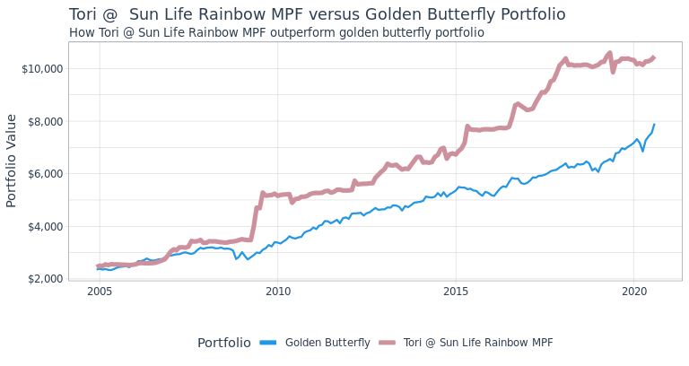

```python
%%R -i fig1,fig2 -w 8 -h 4.25 --units in -r 96
print(fig1)
print(fig2)
```